# 09.Example 2

Modified

Fr 2024-09-06 06:54

## Given:

Experiments have been conducted on a metallic cylinder $12.7\ \mathrm{mm}$ in diameter and $94\ \mathrm{mm}$ long. The cylinder is heated internally by an electrical heater and is subjected to a cross flow of air in a low-speed wind tunnel. Under a specific set of operating conditions for which the upstream air velocity and temperature were maintained at $V = 10\ \frac{\mathrm{m}}{\mathrm{s}}$ and $26.2\ \mathrm{°C}$, respectively, the heater power dissipation was measured to be $P = 46\ \mathrm{W}$, while the average cylinder surface temperature was determined to be $T_s = 128.4\ \mathrm{°C}$. It is estimated that $15.0\%$ of the power dissipation is lost through the cumulative effect of surface radiation and conduction through the end pieces.

Figure 1: System

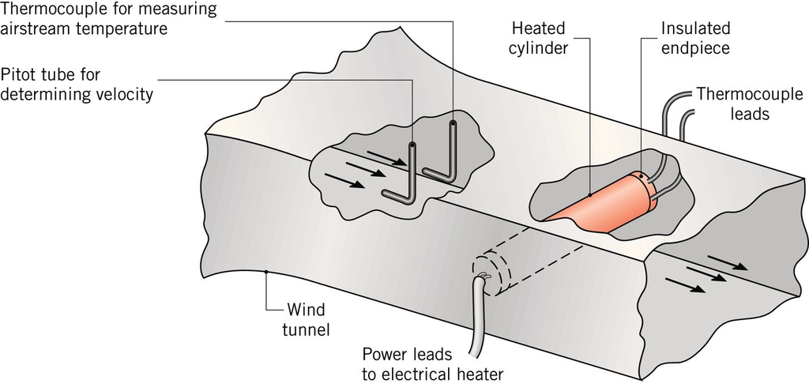

## Required:

1. Determine the convection heat transfer coefficient from the experimental observations.
2. Compare the experimental result with the convection coefficient computed from an appropriate correlation.

## Solution:

Start first by defining all of the given values.

$$D = 12.7\ \mathrm{mm}$$
$$L = 94\ \mathrm{mm}$$
$$V = 10\ \frac{\mathrm{m}}{\mathrm{s}}$$
$$T_\infty = 26.2\ \mathrm{°C} = 299.35\ \mathrm{K}$$
$$P = 46\ \mathrm{W}$$
$$T_s = 128.4\ \mathrm{°C} = 401.55\ \mathrm{K}$$
$$f_l = 15.0\%$$

A drawing of the actual component being analyzed is shown below.

Figure 2: System Drawing

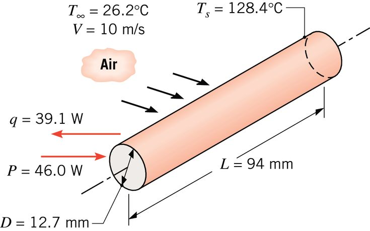

The heat rate as given by experimental observations is

$$q=\bar{h}A_s\left( T_s - T_\infty \right)$$

Solving for the average convective coefficient shows

$$\bar{h}=\frac{q}{A_s \left( T_s - T_\infty \right)}$$

Reviewing the expression shows that the heat rate $q$ and the surface area $A_s$ must be known. The heat rate is found by the power output. Taking into account the loss through radiation and the ends of the cylinder, the heat rate is

$$q = (1-f_l) P = 39.1\ \mathrm{W}$$

The surface area is given by

$$A_s = \pi D L = 37.5\ \mathrm{cm}^{2}$$

The average convective coefficient is then found by

Answer (a): $\bar{h}_1 = \frac{q}{A_s (T_s - T_\infty)} = 102.0\ \frac{\mathrm{W}}{\left(\mathrm{K} \cdot \mathrm{m}^{2}\right)}$

The film temperature is given by

$$T_f = \frac{T_s+T_\infty}{2} = 350.4\ \mathrm{K} = 77.3\ \mathrm{°C}$$

Going to Table A.4 @ $T_f$ shows that interpolation is needed. This is shown below.

$$T_A = 350\ \mathrm{K} = 76.9\ \mathrm{°C}$$
$$T_B = 400\ \mathrm{K} = 126.9\ \mathrm{°C}$$
$$\nu_A = 2.092\times 10^{-5}\ \frac{\mathrm{m}^{2}}{\mathrm{s}}$$
$$\nu_B = 2.641\times 10^{-5}\ \frac{\mathrm{m}^{2}}{\mathrm{s}}$$
$$\nu = \frac{T_f - T_A}{T_B - T_A}(\nu_B - \nu_A) + \nu_A = 2.097\times 10^{-5}\ \frac{\mathrm{m}^{2}}{\mathrm{s}}$$
$$k_A = 0.03\ \frac{\mathrm{W}}{\left(\mathrm{K} \cdot \mathrm{m}\right)}$$
$$k_B = 0.0338\ \frac{\mathrm{W}}{\left(\mathrm{K} \cdot \mathrm{m}\right)}$$
$$k = \frac{T_f - T_A}{T_B - T_A}(k_B - k_A) + k_A = 30.03\ \frac{\mathrm{mW}}{\left(\mathrm{K} \cdot \mathrm{m}\right)}$$
$$Pr_A = 0.7$$
$$Pr_B = 0.69$$
$$Pr = \frac{T_f - T_A}{T_B - T_A}(Pr_B - Pr_A) + Pr_A = 0.6999$$

The Reynolds number for flow around a cylinder is defined as

$$Re_D = \frac{V D}{\nu} = 6056.4$$

Referring to Table 9.1 from the lecture notes, the following empirical relation is valid

$$\bar{Nu}_D = C Re_D^{m} Pr^{\frac{1}{3}} = 37.27$$

where $C = 0.193$ and $m = 0.618$.

Using the definition of the Nusselt number, the average convective coefficient may be found. This is shown below.

$$\bar{Nu}_D=\frac{\bar{h} D}{k}$$

Solving for $\bar{h}$ shows

Answer (b): $\bar{h}_2 = \frac{\bar{Nu_D} k}{D} = 88.13\ \frac{\mathrm{W}}{\left(\mathrm{K} \cdot \mathrm{m}^{2}\right)}$

The percent difference between the two methods is given by

$$\% Diff = \Biggr\lvert \frac{\bar{h}_2 - \bar{h}_1}{\frac{\bar{h}_2+ \bar{h}_1}{2}} \Biggr\rvert = 14.6 \%$$